# Practical Machine Learning Course Project

Sarah Fogel

Wednesday, June 6, 2015

## Synopsis

This report adresses the creation of a prediction algorithm for determining the class of bicep curl (correct form or one of four incorrect forms) based on input from sensors on various points on a person’s body. This analysis finds that a random forest prediction provides the best chance for correct predictions. The data for this project come from this source: http://groupware.les.inf.puc-rio.br/har.

## Data Processing and Exploratory Analysis

The data is first read in as-is from a downloaded file in the working directory. It is split into a training set and a testing set

Then we take a look at the data in the training set to begin identifying possible transformations that should be performed or variables that should be removed from consideration. The test set will be ignored during the analysis except to perform the same transformations on that data as are done to the training set.

Most of the results of the exploration will not be reproduced here for the sake of brevity.

```r
# How big is the data set?
    dim(training)
```

```
## [1] 19622   160
```

```r
# What are the first 15 variables in the data set?
    head(names(training), 15)
```

```
##  [1] "X"                    "user_name"            "raw_timestamp_part_1"
##  [4] "raw_timestamp_part_2" "cvtd_timestamp"       "new_window"
##  [7] "num_window"           "roll_belt"            "pitch_belt"
## [10] "yaw_belt"             "total_accel_belt"     "kurtosis_roll_belt"
## [13] "kurtosis_picth_belt"  "kurtosis_yaw_belt"    "skewness_roll_belt"
```

Since it would be counter-productive for a prediction algorithm to be dependent on the specific person who performed the exercise or the time when they performed the exercise, those varibles, as well as the index, will be removed.

Many of the variables have more than 95% of the observations missing. It was assumed that this data would a) likely be missing in any new data collected and b) unlikely to contribute much to tuning a prediction algorithm, so all of those variables were removed.

At the same time as a “clean” training set was created, a valdiation set was partitioned off to allow for “out of sample” validation later on in the prediction algorithm selection process. 20% of the training set was used for this validation set.

```r
    trainIndex<-createDataPartition(training[,160], p=.8, list=FALSE)

    validationclean<-training[-trainIndex,-unhelpfulVariables]
    trainingclean<-training[trainIndex, -unhelpfulVariables]
    testingclean<-testing[-unhelpfulVariables]
```

The remaining varibles were examined for low variability, which would indicate that they are unlikely to contribute substantially to a prediction algorithm.

Number of variables with near zero variability:

```
## [1] 0
```

No variables were found to have near zero variability.

The 53 variables remaining in the data set are: roll, pitch, and yaw of each of 4 sensors(12); total acceleration of 4 sensors(4); acceleration in 3 directions of 4 sensors (12); gyroscopic forces in 3 directions on 4 sensors (12); magnetic force in 3 directions on 4 sensors (12); and class of exercise (1)

Many of the remaining variables are non-normal; many were bi-modal in shape and some were skewed. No transformations were performed because the prediction methods used were primarily non-linear and could handle non-normal data. A sample of the varibles are plotted below to demonstrate the variety of distributions.

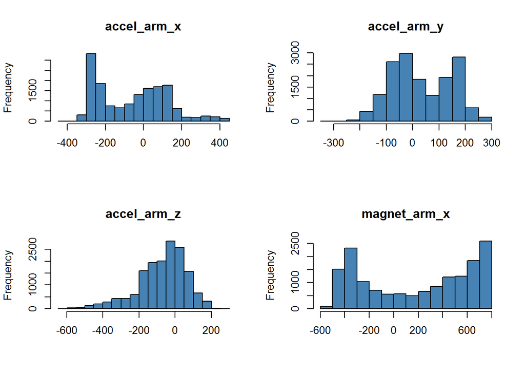

## Model Building and Selection

Several models were fit using the caret package on the training data. These were a classification tree model (rpart), a random forest model (rf), a random forest model using principal components (rf.pca), and a stochastic gradient boosting model (gbm).

```r
    set.seed(333)
# Classification tree
    rpart.model<-train(trainingclean[,1:52], trainingclean[,53], method="rpart")
# Random Forest
    rf.model<-train(trainingclean[,1:52], trainingclean[,53], method="rf")

# Prepare principal components
    preProc<-preProcess(trainingclean[,1:52], method="pca", thresh=.9)
    pcatrain<- predict(preProc, trainingclean[,1:52])
    pcavalidation<- predict(preProc,validationclean[,1:52])

# Principal components random forest
    rf.pca.model<-train(pcatrain, trainingclean[,53], method="rf")

# Stochastic gradient boosting model
    gbm.model<-train(trainingclean[,1:52], trainingclean[,53], method="gbm")
```

Each of these models was created using bootstrapping validation to select the parameters. Since the parameters were selected using this form of validation, another form must be used to estimate the out of sample error. This was determined by comparing the bicep curl classes in the validation set (which was removed from the training set prior to training the models) to the predicted values based on each model. The results for each model are listed below:

Classification Tree Model

```
## Confusion Matrix and Statistics
##
##           Reference
## Prediction   A   B   C   D   E
##          A 999  23  89   0   5
##          B 329 250 180   0   0
##          C 340  21 323   0   0
##          D 289 108 246   0   0
##          E 100  93 187   0 341
##
## Overall Statistics
##
##                Accuracy : 0.4876
##                  95% CI : (0.4719, 0.5034)
##     No Information Rate : 0.5243
##     P-Value [Acc > NIR] : 1
##
##                   Kappa : 0.3299
##  Mcnemar's Test P-Value : NA
##
## Statistics by Class:
##
##                      Class: A Class: B Class: C Class: D Class: E
## Sensitivity            0.4857  0.50505  0.31512       NA  0.98555
## Specificity            0.9373  0.85152  0.87543   0.8361  0.89377
## Pos Pred Value         0.8952  0.32938  0.47222       NA  0.47295
## Neg Pred Value         0.6231  0.92257  0.78327       NA  0.99844
## Prevalence             0.5243  0.12618  0.26128   0.0000  0.08820
## Detection Rate         0.2547  0.06373  0.08233   0.0000  0.08692
## Detection Prevalence   0.2845  0.19347  0.17436   0.1639  0.18379
## Balanced Accuracy      0.7115  0.67828  0.59528       NA  0.93966
```

Random Forest Model

```
## Confusion Matrix and Statistics
##
##           Reference
## Prediction    A    B    C    D    E
##          A 1116    0    0    0    0
##          B    3  756    0    0    0
##          C    0    8  676    0    0
##          D    0    0   10  633    0
##          E    0    0    0    2  719
##
## Overall Statistics
##
##                Accuracy : 0.9941
##                  95% CI : (0.9912, 0.9963)
##     No Information Rate : 0.2852
##     P-Value [Acc > NIR] : < 2.2e-16
##
##                   Kappa : 0.9926
##  Mcnemar's Test P-Value : NA
##
## Statistics by Class:
##
##                      Class: A Class: B Class: C Class: D Class: E
## Sensitivity            0.9973   0.9895   0.9854   0.9969   1.0000
## Specificity            1.0000   0.9991   0.9975   0.9970   0.9994
## Pos Pred Value         1.0000   0.9960   0.9883   0.9844   0.9972
## Neg Pred Value         0.9989   0.9975   0.9969   0.9994   1.0000
## Prevalence             0.2852   0.1947   0.1749   0.1619   0.1833
## Detection Rate         0.2845   0.1927   0.1723   0.1614   0.1833
## Detection Prevalence   0.2845   0.1935   0.1744   0.1639   0.1838
## Balanced Accuracy      0.9987   0.9943   0.9915   0.9969   0.9997
```

Random Forest Model using Principal Components

```
## Confusion Matrix and Statistics
##
##           Reference
## Prediction    A    B    C    D    E
##          A 1109    0    2    3    2
##          B   17  735    6    0    1
##          C    2   14  664    4    0
##          D    1    0   26  613    3
##          E    0    5    8    4  704
##
## Overall Statistics
##
##                Accuracy : 0.975
##                  95% CI : (0.9696, 0.9797)
##     No Information Rate : 0.2878
##     P-Value [Acc > NIR] : < 2.2e-16
##
##                   Kappa : 0.9684
##  Mcnemar's Test P-Value : NA
##
## Statistics by Class:
##
##                      Class: A Class: B Class: C Class: D Class: E
## Sensitivity            0.9823   0.9748   0.9405   0.9824   0.9915
## Specificity            0.9975   0.9924   0.9938   0.9909   0.9947
## Pos Pred Value         0.9937   0.9684   0.9708   0.9533   0.9764
## Neg Pred Value         0.9929   0.9940   0.9870   0.9966   0.9981
## Prevalence             0.2878   0.1922   0.1800   0.1591   0.1810
## Detection Rate         0.2827   0.1874   0.1693   0.1563   0.1795
## Detection Prevalence   0.2845   0.1935   0.1744   0.1639   0.1838
## Balanced Accuracy      0.9899   0.9836   0.9671   0.9866   0.9931
```

Stochastic Gradient Boosting Model

```
## Confusion Matrix and Statistics
##
##           Reference
## Prediction    A    B    C    D    E
##          A 1107    6    1    1    1
##          B   33  705   20    1    0
##          C    0   23  644   17    0
##          D    1    2   18  615    7
##          E    2    9    7   16  687
##
## Overall Statistics
##
##                Accuracy : 0.9579
##                  95% CI : (0.9512, 0.964)
##     No Information Rate : 0.2914
##     P-Value [Acc > NIR] : < 2.2e-16
##
##                   Kappa : 0.9468
##  Mcnemar's Test P-Value : 1.615e-05
##
## Statistics by Class:
##
##                      Class: A Class: B Class: C Class: D Class: E
## Sensitivity            0.9685   0.9463   0.9333   0.9462   0.9885
## Specificity            0.9968   0.9830   0.9876   0.9914   0.9895
## Pos Pred Value         0.9919   0.9289   0.9415   0.9565   0.9528
## Neg Pred Value         0.9872   0.9874   0.9858   0.9893   0.9975
## Prevalence             0.2914   0.1899   0.1759   0.1657   0.1772
## Detection Rate         0.2822   0.1797   0.1642   0.1568   0.1751
## Detection Prevalence   0.2845   0.1935   0.1744   0.1639   0.1838
## Balanced Accuracy      0.9826   0.9647   0.9605   0.9688   0.9890
```

The higest out of sample accuracy for any of these models is the random forrest model. Therefore, that will be the selected model.

The expected out of sample accuracy for this model is .99.

## Predicting with the Model

The random forest model can now be applied to the test set to make the final predictions. The predictions for the test set were submitted through the online submission function and all were rated correct.